# Welcome to *collapse*: Advanced and Fast Data Transformation in R

Sebastian Krantz

2020-06-05

[figure not shown]

# Introduction

*collapse* was released on CRAN end of March. The current version 1.2.1 performs well on all operating systems, passing > 5600 unit tests covering all core functionality, thus a good point to start introducing the package to a larger audience. *collapse* has 2 main aims:

1. To facilitate complex data transformation and exploration tasks in R. *(In particular grouped and weighted statistical computations, advanced aggregation of multi-type data, advanced transformations of time-series and panel-data, and the manipulation of lists)*
2. To help make R code fast, flexible, parsimonious and programmer friendly. *(Provide order of magnitude performance improvements via extensive use of C++ and highly optimized R code, broad attribute preserving object orientation, and infrastructure for fast grouped programming)*

It can be installed in R using:

```r
install.packages('collapse')

# See Documentation
help('collapse-documentation')
```

With this post I want to formally introduce *collapse* and share some of the motivation and history of it. Then I will provide a basic demonstration of important features, and end with a small benchmark comparing *collapse* to *dplyr* and *data.table*. The key features and functions of the package are summarized in the figure below.

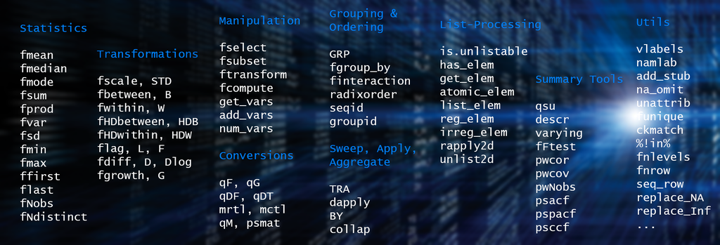

*collapse* Core Functions

I start with the motivation. You can skip this if you like, but it will put things in a proper perspective.

# Some Motivation and History

I work as an applied economist in the broader fields of macroeconomics, trade and development. As such I frequently encounter survey data such as household or enterprise surveys, longitudinal / panel data such as cross-country, trade, geospatial panels or panel-surveys, and multivariate macroeconomic data such as groups of monthly or quarterly economic time-series.

On this data I usually require various grouped computations, such as aggregating multi-type data (including groupwise-weighted statistics for survey data or trade-share weighted stuff etc)., grouped scaling or centering panel data in preparation for some econometric techniques I program by hand (sometimes with weights on a panel-survey), and various time-series stuff such as computing sequences of lags / leads, (iterated) differences, quasi-differnces and growth rates / log-differences on large panel data (i.e. geospatial panels) and large groups of macroeconomic time-series. I also found myself often faced with recursive extraction and unlisting / row-binding problems, particularly for multivariate time-series stuff like impulse responses from a VAR which I like to turn into a data.frame and visualize with *ggplot2*.

With these demands I soon realized that neither the *tidyverse* nor *data.table* were servicing me very well. The reasons being the requirement of converting to data.frame/data.table/tibble, limited support for weighted or grouped and weighted computations, efficient time-series and panel-data transformations, and, (in my opinion) limited utility for programming because of non-standard evaluation and R overhead. I also found some object-oriented packages quite useful, especially *plm* for panel-data manipulation, but soon bumped into serious constraints regarding performance and scope of implementation. The same holds true for useful model-extraction packages like *broom*, *insight*, *parameters* etc.: They don’t support multivariate time-series stuff and lack some flexibility in the format and type of information extracted.

Thus I came to the conclusion that if I wanted to take things further in R, I had to create my own data manipulation package with the following properties:

- A broad object-oriented approach with generic functions supporting vectors, matrices, data.frames and lists. The approach should preserve object classes and avoid unnecessary conversions and loss of attributes (such as attributes of time-series, data.frame’s or columns in a data.frame).
- Support very fast grouped and weighted computations (aggregations, transformations, time-series and panel-data stuff and general replacing and sweeping out of statistics) on all those objects.
- Provide facilities for efficient (grouped) programming in R using standard evaluation (so that I could write panel-estimators etc. with a few lines of expressive code).
- Provide various useful functions that would facilitate frequent complex tasks, such as (weighted) aggregation of multi-type data, processing lists (i.e. recursive search and extraction from list-like objects and recursive unlisting to data.frame), and some essential tools such as panel-data statistics and autocorrelation functions, support for variable labels etc..

These objectives synthesized into an ambitious project over time. I started about 2 years ago with the functions `collap` and `qsu` for multi-type data aggregation and panel-summary statistics. I soon discovered that my R code was somewhat complex and did not deliver the performance I had hoped for. For a while I thought about using *data.table* backend, but then I encountered *Rcpp* and studied *data.table* source a bit. I discovered that developing grouped statistical functions with *Rcpp* and combining them with *data.table*’s C-functions for fast radix-order based grouping could produce serially compiled code that was faster than *data.table* itself run with two threads on my laptop. Thus I decided to develop sets of grouped and weighted functions and transformation operators, and service them with grouping objects based on *data.table*’s grouping C-code. This allowed a much faster and more flexible package than using a backend. I also discovered that I could optimize critical base R operations such as selecting columns or subsetting data.frames using efficient primitives and some C/C++ code. Thus performance became an objective and I aimed to

- Develop the fastest serially compiled package for data manipulation in R, use C/C++ code whenever sensible and thoroughly optimize the R code.

Then I thought that this could also become a quite useful add-on package for users of *dplyr* / *tidyverse*, *data.table* or specialized object oriented packages like *plm*. Thus I decided to integrate *collapse* into these programming environments:

- Offer seamless integration with *dplyr*, *data.table* and *plm* through support of relevant classes (*grouped_df*, *data.table*, *pseries*, *pdata.frame*), some extra methods and added non-standard evaluation features.

I also thought that the *collapse* API for grouped programming in R, with fast C++ based grouped functions serviced with grouping objects efficiently created and accessed in R, could be useful for other developers, both in R and C++. Thus I opted to make this all available to the user and document it. I will shortly write a second post covering fast grouped programming with *collapse*.

- Make *collapse* maximally programmer / developer friendly, through making available fast grouping mechanisms, core methods and some utilities facilitating efficient grouped programming in R.

Regarding documentation, I do not really like the default R format of function-Rd pages supplemented by vignettes. I got inspired by *Mathematica* which has a beautiful structured documentation starting from a central overview page. Thus my final development objective:

- Create a structured, horizonatally and vertically integrated package documentation which can be called from the R console.

*collapse* also has some quite extensive vignettes supplementing the built-in documentation and discussing the integration with *dplyr* and *plm*.

# Demonstration

I start by briefly demonstrating the *Fast Statistical Functions*, which are a central feature of *collapse*. Currently there are 13 of them (`fmean`, `fmedian`, `fmode`, `fsum`, `fprod`, `fsd`, `fvar`, `fmin`, `fmax`, `ffirst`, `flast`, `fNobs` and `fNdistinct`), they are all S3 generic and support fast grouped computations on vectors, matrices, data.frame’s, lists and grouped tibbles (class *grouped_df*). Calling these functions on different objects yields simple column-wise statistical computations:

```r
library(collapse)
v <- iris$Sepal.Length
d <- num_vars(iris)    # Saving numeric variables
g <- iris$Species

# Simple statistics
fmean(v)              # vector
```

```
## [1] 5.843333
```

```r
fmean(qM(d))          # matrix (qM is a faster as.matrix)
## Sepal.Length  Sepal.Width Petal.Length  Petal.Width
##     5.843333     3.057333     3.758000     1.199333
fmean(d)              # data.frame
## Sepal.Length  Sepal.Width Petal.Length  Petal.Width
##     5.843333     3.057333     3.758000     1.199333

# Preserving data structure
fmean(qM(d), drop = FALSE)     # still a matrix
```

```
##      Sepal.Length Sepal.Width Petal.Length Petal.Width
## [1,]     5.843333    3.057333        3.758    1.199333
```

```r
fmean(d, drop = FALSE)         # still a data.frame
```

```
##   Sepal.Length Sepal.Width Petal.Length Petal.Width
## 1     5.843333    3.057333        3.758    1.199333
```

The functions `fmean`, `fsum`, `fprod`, `fmode`, `fvar` and `fsd` additionally support weights[^1].

```r
# Weighted statsitics, similarly for vectors and matrices ...
w <- abs(rnorm(fnrow(iris)))
fmean(d, w = w)
## Sepal.Length  Sepal.Width Petal.Length  Petal.Width
##     5.786124     3.023277     3.749337     1.204637
```

The second argument of these functions is called `g` and supports vectors or lists of grouping variables for grouped computations. For functions supporting weights, `w` is the third argument. I note that all further examples generalize to computations on vectors and matrices.

```r
# Grouped statistics
fmean(d, g)
```

```
##            Sepal.Length Sepal.Width Petal.Length Petal.Width
## setosa            5.006       3.428        1.462       0.246
## versicolor        5.936       2.770        4.260       1.326
## virginica         6.588       2.974        5.552       2.026
```

```r
# Groupwise-weighted statistics
fmean(d, g, w)
```

```
##            Sepal.Length Sepal.Width Petal.Length Petal.Width
## setosa         4.948926    3.374360     1.422756   0.2473579
## versicolor     5.942927    2.773120     4.229338   1.3229815
## virginica      6.429374    2.950748     5.489620   2.0053383
```

Grouping becomes more efficient when factors or grouping objects are passed to `g`. Factors can efficiently be created using the function `qF`, and grouping objects are efficiently created with the function `GRP`[^2] (more in a future post about programming). In addition, all functions support transformations through the `TRA` argument.

```r
# Simple Transformations
head(fvar(v, TRA = "replace"))  # replacing values with the overall variance
```

```
## [1] 0.6856935 0.6856935 0.6856935 0.6856935 0.6856935 0.6856935
```

```r
head(fsd(v, TRA = "/"))         # dividing by the overall standard-deviation (scaling)
```

```
## [1] 6.158928 5.917402 5.675875 5.555112 6.038165 6.521218
```

```r
# Grouped transformations
head(fvar(v, g, TRA = "replace"))  # replacing values with the group variance
```

```
## [1] 0.124249 0.124249 0.124249 0.124249 0.124249 0.124249
```

```r
head(fsd(v, g, TRA = "/"))         # grouped scaling
```

```
## [1] 14.46851 13.90112 13.33372 13.05003 14.18481 15.31960
```

```r
head(fmin(v, g, TRA = "-"))        # setting the minimum value in each species to 0
```

```
## [1] 0.8 0.6 0.4 0.3 0.7 1.1
```

```r
head(fsum(v, g, TRA = "/"))        # dividing by the sum (proportions)
```

```
## [1] 0.02037555 0.01957651 0.01877747 0.01837795 0.01997603 0.02157411
```

```r
head(fmedian(v, g, TRA = "-"))     # de-median
```

```
## [1]  0.1 -0.1 -0.3 -0.4  0.0  0.4
```

```r
head(ffirst(v, g, TRA = "%%"))     # taking modulus of first group-value, etc ...
```

```
## [1] 0.0 4.9 4.7 4.6 5.0 0.3
```

```r
# Grouped and weighted transformations
head(fsd(v, g, w, "/"), 3)         # Weighted scaling
```

```
## [1] 13.80331 13.26200 12.72070
```

```r
head(fmode(d, g, w, "replace"), 3) # replace with weighted statistical mode
```

```
##   Sepal.Length Sepal.Width Petal.Length Petal.Width
## 1          5.1         3.2          1.4         0.2
## 2          5.1         3.2          1.4         0.2
## 3          5.1         3.2          1.4         0.2
```

Currently there are 10 different replacing or sweeping operations supported by `TRA`, see `?TRA`. `TRA` is not only an argument to these statistical functions, it is also a function that can be called in its own right. It performs simple and grouped replacing and sweeping operations:

```r
head(TRA(v, fmedian(v), "-"))                        # Same as fmedian(v, TRA = "-")
```

```
## [1] -0.7 -0.9 -1.1 -1.2 -0.8 -0.4
```

```r
head(TRA(d, BY(d, g, quantile, 0.05), "replace", g)) # Replace values with 5% percentile by species
```

```
##   Sepal.Length Sepal.Width Petal.Length Petal.Width
## 1          4.4           3          1.2         0.1
## 2          4.4           3          1.2         0.1
## 3          4.4           3          1.2         0.1
## 4          4.4           3          1.2         0.1
## 5          4.4           3          1.2         0.1
## 6          4.4           3          1.2         0.1
```

I have just used the function `BY`, which is also generic for split-apply-combine computing with user-supplied functions. Another useful function is `dapply` (data-apply), which supports quite efficient column- and row-wise operations on matrices and data.frames using user-supplied functions.

Some common panel-data transformations like between- and within-transformations (averaging and centering using the mean) are implemented slightly more memory efficient in the functions `fbetween` and `fwithin`. The function `fscale` also exists for fast (grouped, weighted) scaling and centering (standardizing) and mean-preserving scaling. These functions provide further options for data harmonization, such as centering on the overall data mean or scaling to the within-group standard deviation[^3] (as shown below), as well as scaling / centering to arbitrary supplied means and standard deviations.

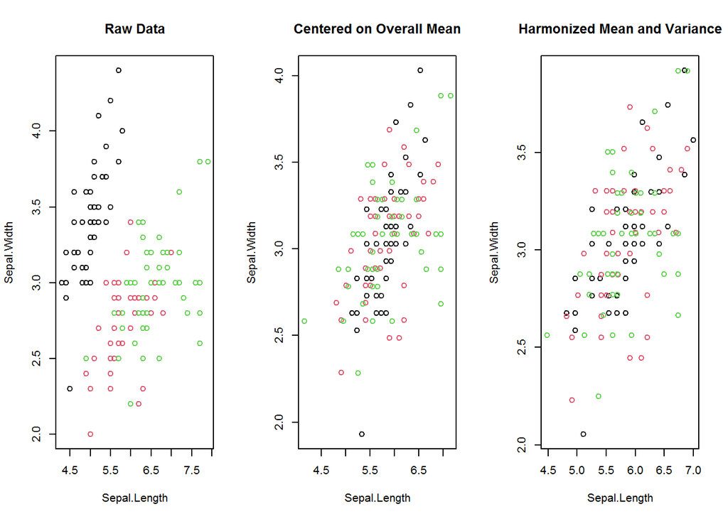

```r
oldpar <- par(mfrow = c(1,3))
plot(get_vars(d, 1:2), col = g, main = "Raw Data")
plot(fwithin(get_vars(d, 1:2), g, mean = "overall.mean"), col = g,
     main = "Centered on Overall Mean")
plot(fscale(get_vars(d, 1:2), g, mean = "overall.mean", sd = "within.sd"), col = g,
     main = "Harmonized Mean and Variance")
```

```r
par(oldpar)
```

The function `get_vars` is 2x faster than `[.data.frame`, attribute-preserving, and also supports column selection using functions or regular expressions. It’s replacement version `get_vars<-` is 6x faster than `[<-.data.frame`. Apart from `fbetween` and `fwithin`, the functions `fHDbetween` and `fHDwithin` can average or center data on multiple groups, and they can also project out continuous variables alongside (i.e. they provide fitted values or residuals from regression problems which may or may not involve one or more factors).

For the manipulation of time-series and panel-series, *collapse* offers the functions `flag`, `fdiff` and `fgrowth`.

```r
head3 <- function(x) head(x, 3L)
head3(flag(EuStockMarkets, -1:1))      # A sequence of lags and leads
```

```
##       F1.DAX     DAX  L1.DAX F1.SMI    SMI L1.SMI F1.CAC    CAC L1.CAC F1.FTSE   FTSE L1.FTSE
## [1,] 1613.63 1628.75      NA 1688.5 1678.1     NA 1750.5 1772.8     NA  2460.2 2443.6      NA
## [2,] 1606.51 1613.63 1628.75 1678.6 1688.5 1678.1 1718.0 1750.5 1772.8  2448.2 2460.2  2443.6
## [3,] 1621.04 1606.51 1613.63 1684.1 1678.6 1688.5 1708.1 1718.0 1750.5  2470.4 2448.2  2460.2
```

```r
head3(fdiff(EuStockMarkets, 0:1, 1:2)) # First and second difference of each variable
```

```
##          DAX D1.DAX D2.DAX    SMI D1.SMI D2.SMI    CAC D1.CAC D2.CAC   FTSE D1.FTSE D2.FTSE
## [1,] 1628.75     NA     NA 1678.1     NA     NA 1772.8     NA     NA 2443.6      NA      NA
## [2,] 1613.63 -15.12     NA 1688.5   10.4     NA 1750.5  -22.3     NA 2460.2    16.6      NA
## [3,] 1606.51  -7.12      8 1678.6   -9.9  -20.3 1718.0  -32.5  -10.2 2448.2   -12.0   -28.6
```

I note that all attributes of the time-series matrix `EuStockMarkets` were preserved, the use of `head` just suppresses the print method.

To take things a bit further, let’s consider some multilevel / panel data:

```r
# World Bank World Development Data - supplied with collapse
head3(wlddev)
```

```
##       country iso3c       date year decade     region     income  OECD PCGDP LIFEEX GINI       ODA
## 1 Afghanistan   AFG 1961-01-01 1960   1960 South Asia Low income FALSE    NA 32.292   NA 114440000
## 2 Afghanistan   AFG 1962-01-01 1961   1960 South Asia Low income FALSE    NA 32.742   NA 233350000
## 3 Afghanistan   AFG 1963-01-01 1962   1960 South Asia Low income FALSE    NA 33.185   NA 114880000
```

All variables in this data have labels stored in a ‘label’ attribute (the default if you import with *haven*). Variable labels can be accessed and set using `vlabels` and `vlabels<-`, and viewed together with names and classes using `namlab`. In general variable labels and other attributes will be preserved in when working with *collapse*. *collapse* provides some of the fastest and most advanced summary statistics:

```r
# Distinct value count
fNdistinct(wlddev)
## country   iso3c    date    year  decade  region  income    OECD   PCGDP  LIFEEX    GINI     ODA
##     216     216      59      59       7       7       4       2    8995   10048     363    7564
# Use descr(wlddev) for a detailed description of each variable

# Checking for within-country variation
varying(wlddev, ~ iso3c)
## country    date    year  decade  region  income    OECD   PCGDP  LIFEEX    GINI     ODA
##   FALSE    TRUE    TRUE    TRUE   FALSE   FALSE   FALSE    TRUE    TRUE    TRUE    TRUE

# Panel-data statistics: Summarize GDP and GINI overall, between and within countries
qsu(wlddev, pid = PCGDP + GINI ~ iso3c, vlabels = TRUE, higher = TRUE)
## , , PCGDP: GDP per capita (constant 2010 US$)
##
##            N/T      Mean        SD        Min        Max  Skew   Kurt
## Overall   8995  11563.65  18348.41     131.65  191586.64  3.11  16.96
## Between    203  12488.86  19628.37      255.4  141165.08  3.21  17.25
## Within   44.31  11563.65   6334.95  -30529.09   75348.07   0.7  17.05
##
## , , GINI: GINI index (World Bank estimate)
##
##           N/T   Mean    SD    Min    Max  Skew  Kurt
## Overall  1356   39.4  9.68   16.2   65.8  0.46  2.29
## Between   161  39.58  8.37  23.37  61.71  0.52  2.67
## Within   8.42   39.4  3.04  23.96   54.8  0.14  5.78

# All of that by region, only summarizing GDP, not computing higher moments
aperm(qsu(wlddev, by = ~ region, pid = PCGDP ~ iso3c))[,, 1:2]
## , , East Asia & Pacific
##
##                  N/T         Mean           SD          Min          Max
## Overall   1391.00000  10337.04635  14094.83383    131.96337  72183.30331
## Between     34.00000  10337.04635  12576.61999    410.20040  40046.40886
## Within      40.91176  11563.65287   6363.40871 -11892.07023  50475.98727
##
## , , Europe & Central Asia
##
##                  N/T         Mean           SD          Min          Max
## Overall   2084.00000  25664.80639  26181.67097    367.04926 191586.63965
## Between     56.00000  25664.80639  24008.10062    788.02286 141165.08286
## Within      37.21429  11563.65287  10444.66367 -30529.09280  75348.06699

# Within-country correlations with p-value and observation count
pwcor(fwithin(get_vars(wlddev, 9:12), wlddev$iso3c), N = TRUE, P = TRUE)
```

```
##               PCGDP        LIFEEX         GINI          ODA
## PCGDP    1   (8995)   .30* (8398) -.03  (1342) -.01  (6852)
## LIFEEX  .30* (8398)   1   (11068) -.15* (1353)  .14* (7746)
## GINI   -.03  (1342)  -.15* (1353)   1   (1356)  -.02  (951)
## ODA    -.01  (6852)   .14* (7746)  -.02  (951)   1   (8336)
```

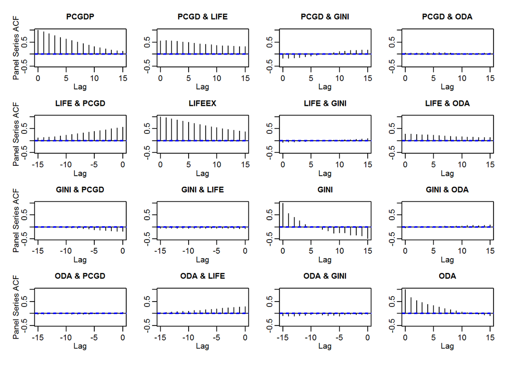

```r
# Panel-data ACF: Efficient grouped standardizing, and computing covariance with panel-lags
# (same as stats version, I might add psAcf to also give the forecast version)
psacf(wlddev, ~ iso3c, ~ year, cols = 9:12)
```

For fast grouped statistics we can keep programming in standard evaluation as before, or we can use piped expressions.

```r
head3(fmean(get_vars(wlddev, 9:12), get_vars(wlddev, c("region", "income"))))
```

```
##                                             PCGDP   LIFEEX     GINI       ODA
## East Asia & Pacific.High income         26042.280 73.22799 32.80000 177672692
## East Asia & Pacific.Lower middle income  1621.178 58.83796 36.21081 503484782
## East Asia & Pacific.Upper middle income  3432.559 66.41750 42.29524 242080501
```

```r
`%>%` <- magrittr::`%>%`
wlddev %>% fgroup_by(region, income) %>% fselect(PCGDP:ODA) %>% fmean %>% head3
```

```
##                region              income     PCGDP   LIFEEX     GINI       ODA
## 1 East Asia & Pacific         High income 26042.280 73.22799 32.80000 177672692
## 2 East Asia & Pacific Lower middle income  1621.178 58.83796 36.21081 503484782
## 3 East Asia & Pacific Upper middle income  3432.559 66.41750 42.29524 242080501
```

I note that the default is `na.rm = TRUE` for all *collapse* functions. I also note that you can also use `dplyr::group_by` and `dplyr::select`, but `fgroup_by` and `fselect` are significantly faster (see benchmark). We can do a weighted aggregation using the variable `ODA` as weights using:

```r
# Weighted group mean: Weighted by ODA
wlddev %>% fgroup_by(region, income) %>% fselect(PCGDP:ODA) %>% fmean(ODA) %>% head3
```

```
##                region              income      sum.ODA    PCGDP   LIFEEX     GINI
## 1 East Asia & Pacific         High income  64672860000 2332.191 64.61962       NA
## 2 East Asia & Pacific Lower middle income 346397530000 1411.414 62.52892 36.23540
## 3 East Asia & Pacific Upper middle income 106273340000 1706.960 68.76040 44.63886
```

Note that in this case by default (`keep.w = TRUE`) the sum of the weights is also computed and saved. *collapse* also has its own data aggregation command called `collap`. It is in many ways more flexible, for example you can apply multiple functions to each column and efficiently reshape the result.

```r
collap(wlddev, by = ~ region + income, FUN = list(fmean, fsd), cols = 9:12) %>% head3
```

```
##                region              income fmean.PCGDP  fsd.PCGDP fmean.LIFEEX fsd.LIFEEX fmean.GINI
## 1 East Asia & Pacific         High income   26042.280 14593.6195     73.22799   6.363266   32.80000
## 2 East Asia & Pacific Lower middle income    1621.178   908.9503     58.83796   9.383965   36.21081
## 3 East Asia & Pacific Upper middle income    3432.559  2418.0954     66.41750   6.451834   42.29524
##   fsd.GINI fmean.ODA   fsd.ODA
## 1 1.222020 177672692 337269272
## 2 4.830619 503484782 693802678
## 3 3.640621 242080501 604615277
```

```r
collap(wlddev, by = ~ region + income, FUN = list(fmean, fsd), cols = 9:12, return = "long") %>% head3
```

```
##   Function              region              income     PCGDP   LIFEEX     GINI       ODA
## 1    fmean East Asia & Pacific         High income 26042.280 73.22799 32.80000 177672692
## 2    fmean East Asia & Pacific Lower middle income  1621.178 58.83796 36.21081 503484782
## 3    fmean East Asia & Pacific Upper middle income  3432.559 66.41750 42.29524 242080501
```

`collap` also supports flexible multi-type aggregation, here applying the mean to numeric and statistical mode to categorical data. The default (`keep.col.order = TRUE`) ensures that the data remains in the same order, and, when working with *Fast Statistical Functions*, all column attributes are preserved.

```r
# Applying the mean to numeric and the mode to categorical data (first 2 arguments are 'by' and 'FUN')
collap(wlddev, ~ iso3c + decade, fmean, catFUN = fmode) %>% head3
```

```
##   country iso3c       date   year decade                     region      income  OECD PCGDP   LIFEEX
## 1   Aruba   ABW 1961-01-01 1962.5   1960 Latin America & Caribbean  High income FALSE    NA 66.58583
## 2   Aruba   ABW 1967-01-01 1970.0   1970 Latin America & Caribbean  High income FALSE    NA 69.14178
## 3   Aruba   ABW 1976-01-01 1980.0   1980 Latin America & Caribbean  High income FALSE    NA 72.17600
##   GINI      ODA
## 1   NA       NA
## 2   NA       NA
## 3   NA 33630000
```

```r
# Same as a piped call.. without column reordering
wlddev %>% fgroup_by(iso3c, decade) %>% {
  add_vars(fmode(cat_vars(.)), fmean(get_vars(., 9:12))) # cat_vars selects non-numeric (catgorical) columns
} %>% head3
```

```
##   iso3c decade country       date                     region      income  OECD iso3c decade PCGDP
## 1   ABW   1960   Aruba 1961-01-01 Latin America & Caribbean  High income FALSE   ABW   1960    NA
## 2   ABW   1970   Aruba 1967-01-01 Latin America & Caribbean  High income FALSE   ABW   1970    NA
## 3   ABW   1980   Aruba 1976-01-01 Latin America & Caribbean  High income FALSE   ABW   1980    NA
##     LIFEEX GINI      ODA
## 1 66.58583   NA       NA
## 2 69.14178   NA       NA
## 3 72.17600   NA 33630000
```

```r
# Adding weights: weighted mean and weighted mode (catFUN is 3rd argument)
collap(wlddev, ~ iso3c + decade, fmean, fmode, w = ~ ODA) %>% head3
```

```
##   country iso3c       date year decade                     region      income  OECD PCGDP LIFEEX
## 1   Aruba   ABW 1966-01-01   NA   1960 Latin America & Caribbean  High income    NA    NA     NA
## 2   Aruba   ABW 1975-01-01   NA   1970 Latin America & Caribbean  High income    NA    NA     NA
## 3   Aruba   ABW 1986-01-01 1985   1980 Latin America & Caribbean  High income FALSE    NA 73.181
##   GINI      ODA
## 1   NA       NA
## 2   NA       NA
## 3   NA 33630000
```

```r
# Fully custom aggregation (also possible with weights)
collap(wlddev, ~ iso3c + decade,
            custom = list(fmean = 9:12,
                          fmax = 9:10,
                          flast = cat_vars(wlddev, "indices"),
                          fmode = "GINI")) %>% head3
```

```
##   flast.country iso3c flast.iso3c flast.date decade               flast.region flast.income
## 1         Aruba   ABW         ABW 1966-01-01   1960 Latin America & Caribbean   High income
## 2         Aruba   ABW         ABW 1975-01-01   1970 Latin America & Caribbean   High income
## 3         Aruba   ABW         ABW 1986-01-01   1980 Latin America & Caribbean   High income
##   flast.OECD fmean.PCGDP fmax.PCGDP fmean.LIFEEX fmax.LIFEEX fmean.GINI fmode.GINI fmean.ODA
## 1      FALSE          NA         NA     66.58583      67.435         NA         NA        NA
## 2      FALSE          NA         NA     69.14178      70.519         NA         NA        NA
## 3      FALSE          NA         NA     72.17600      73.181         NA         NA  33630000
```

When working with multiple functions, you can parallelize over them. Time computations on panel-data are also performed fast and simple.

```r
# Panel Lag and lead of PCGDP and LIFEEX
L(wlddev, -1:1, PCGDP + LIFEEX ~ iso3c, ~year) %>% head3
```

```
##   iso3c year F1.PCGDP PCGDP L1.PCGDP F1.LIFEEX LIFEEX L1.LIFEEX
## 1   AFG 1960       NA    NA       NA    32.742 32.292        NA
## 2   AFG 1961       NA    NA       NA    33.185 32.742    32.292
## 3   AFG 1962       NA    NA       NA    33.624 33.185    32.742
```

```r
# Equivalent piped call
wlddev %>% fgroup_by(iso3c) %>% fselect(iso3c, year, PCGDP, LIFEEX) %>% flag(-1:1, year) %>% head3
```

```
##   iso3c year F1.PCGDP PCGDP L1.PCGDP F1.LIFEEX LIFEEX L1.LIFEEX
## 1   AFG 1960       NA    NA       NA    32.742 32.292        NA
## 2   AFG 1961       NA    NA       NA    33.185 32.742    32.292
## 3   AFG 1962       NA    NA       NA    33.624 33.185    32.742
```

```r
# Growth rates: 1 and 10-year
G(wlddev, c(1, 10), 1, ~ iso3c, ~year, cols = 9:12) %>% head3 # or use Dlog
```

```
##   iso3c year G1.PCGDP L10G1.PCGDP G1.LIFEEX L10G1.LIFEEX G1.GINI L10G1.GINI    G1.ODA L10G1.ODA
## 1   AFG 1960       NA          NA        NA           NA      NA         NA        NA        NA
## 2   AFG 1961       NA          NA  1.393534           NA      NA         NA 103.90598        NA
## 3   AFG 1962       NA          NA  1.353002           NA      NA         NA -50.76923        NA
```

Equivalently we can can compute leaded and suitably iterated (log-) differences and growth rates, as well as quasi-(log-)differences. The operators `L` and `G` are shorthands for the functions `flag` and `fgrowth` allowing formula input. Similar operators exist for `fwithin`, `fscale`, etc.

# Benchmark

```r
library(tradestatistics)
# US HS4-level trade from 2000 to 2018
us_trade <- ots_create_tidy_data(years = 2000:2018, reporters = "usa", table = "yrpc")
```

Downloading US product-level trade (HS4) from 2000 to 2018 gives about 2.6 million observations:

```r
fdim(us_trade)
```

```
## [1] 2569787      19
```

```r
head3(us_trade)
```

```
##    year reporter_iso                                                   reporter_fullname_english
## 1: 2017          usa USA, Puerto Rico and US Virgin Islands (excludes Virgin Islands until 1981)
## 2: 2018          usa USA, Puerto Rico and US Virgin Islands (excludes Virgin Islands until 1981)
## 3: 2017          usa USA, Puerto Rico and US Virgin Islands (excludes Virgin Islands until 1981)
##    partner_iso partner_fullname_english section_code section_color section_shortname_english
## 1:         afg              Afghanistan           01       #74c0e2           Animal Products
## 2:         afg              Afghanistan           01       #74c0e2           Animal Products
## 3:         afg              Afghanistan           01       #74c0e2           Animal Products
##         section_fullname_english group_code group_fullname_english product_code
## 1: Live Animals; Animal Products         01          Animals; live         0101
## 2: Live Animals; Animal Products         01          Animals; live         0101
## 3: Live Animals; Animal Products         01          Animals; live         0102
##    product_shortname_english               product_fullname_english export_value_usd
## 1:                    Horses Horses, asses, mules and hinnies; live             3005
## 2:                    Horses Horses, asses, mules and hinnies; live            15699
## 3:                    Bovine                   Bovine animals; live             3436
##    import_value_usd id export_value_usd2 import_value_usd2
## 1:               NA  1           -4270.0                NA
## 2:               NA  1          -15917.5                NA
## 3:               NA  2           -3839.0                NA
```

```r
# 19 years, 221 trading partners, 1222 products, unbalanced panel with product-time gaps...
qDF(rbind(class = vclasses(us_trade), Ndistinct = fNdistinct(us_trade)))
```

```
##              year reporter_iso reporter_fullname_english partner_iso partner_fullname_english
## class     integer    character                 character   character                character
## Ndistinct      19            1                         1         221                      221
##           section_code section_color section_shortname_english section_fullname_english group_code
## class        character     character                 character                character  character
## Ndistinct           22            22                        22                       22         97
##           group_fullname_english product_code product_shortname_english product_fullname_english
## class                  character    character                 character                character
## Ndistinct                     97         1222                      1217                     1222
##           export_value_usd import_value_usd      id export_value_usd2 import_value_usd2
## class              numeric          numeric integer           numeric           numeric
## Ndistinct          1081492           684781  423884           2324825           1161701
```

```r
# Summarizing data between and within partner-product pairs
qsu(us_trade, pid = export_value_usd + import_value_usd ~ partner_iso + product_code)
## , , export_value_usd
##
##               N/T         Mean           SD              Min             Max
## Overall  2,450301  11,054800.6   157,295999                1  2.83030606e+10
## Between    205513  7,268011.31   118,709845                1  1.66436161e+10
## Within      11.92  11,054800.6  68,344396.5  -1.01599067e+10  1.67185229e+10
##
## , , import_value_usd
##
##               N/T         Mean          SD              Min             Max
## Overall  1,248201  31,421502.4  505,644905                1  8.51970855e+10
## Between    130114  16,250758.2  328,538895                1  4.36545695e+10
## Within       9.59  31,421502.4  212,076350  -3.32316111e+10  4.15739375e+10
```

It would also be interesting to summarize the trade flows for each partner, but that would be too large to print to the console. We can however get the `qsu` output as a list of matrices:

```r
# Doing all of that by partner - variance of flows between and within traded products for each partner
l <- qsu(us_trade, export_value_usd + import_value_usd ~ partner_iso, ~ partner_iso + product_code,
         array = FALSE)
str(l)
```

```
## List of 2
##  $ export_value_usd:List of 3
##   ..$ Overall: 'qsu' num [1:221, 1:5] 7250 12427 6692 5941 4017 ...
##   .. ..- attr(*, "dimnames")=List of 2
##   .. .. ..$ : chr [1:221] "afg" "ago" "aia" "alb" ...
##   .. .. ..$ : chr [1:5] "N" "Mean" "SD" "Min" ...
##   ..$ Between: 'qsu' num [1:221, 1:5] 901 1151 872 903 695 ...
##   .. ..- attr(*, "dimnames")=List of 2
##   .. .. ..$ : chr [1:221] "afg" "ago" "aia" "alb" ...
##   .. .. ..$ : chr [1:5] "N" "Mean" "SD" "Min" ...
##   ..$ Within : 'qsu' num [1:221, 1:5] 8.05 10.8 7.67 6.58 5.78 ...
##   .. ..- attr(*, "dimnames")=List of 2
##   .. .. ..$ : chr [1:221] "afg" "ago" "aia" "alb" ...
##   .. .. ..$ : chr [1:5] "N" "Mean" "SD" "Min" ...
##  $ import_value_usd:List of 3
##   ..$ Overall: 'qsu' num [1:221, 1:5] 1157 1547 361 1512 685 ...
##   .. ..- attr(*, "dimnames")=List of 2
##   .. .. ..$ : chr [1:221] "afg" "ago" "aia" "alb" ...
##   .. .. ..$ : chr [1:5] "N" "Mean" "SD" "Min" ...
##   ..$ Between: 'qsu' num [1:221, 1:5] 312 532 167 347 235 ...
##   .. ..- attr(*, "dimnames")=List of 2
##   .. .. ..$ : chr [1:221] "afg" "ago" "aia" "alb" ...
##   .. .. ..$ : chr [1:5] "N" "Mean" "SD" "Min" ...
##   ..$ Within : 'qsu' num [1:221, 1:5] 3.71 2.91 2.16 4.36 2.91 ...
##   .. ..- attr(*, "dimnames")=List of 2
##   .. .. ..$ : chr [1:221] "afg" "ago" "aia" "alb" ...
##   .. .. ..$ : chr [1:5] "N" "Mean" "SD" "Min" ...
```

Now with the function `unlist2d`, we can efficiently turn this into a tidy data.table:

```r
unlist2d(l, idcols = c("Variable", "Trans"), row.names = "Partner", DT = TRUE)
```

```
##               Variable   Trans Partner            N        Mean         SD        Min        Max
##    1: export_value_usd Overall     afg  7250.000000  2170073.97 21176449.3         56 1115125722
##    2: export_value_usd Overall     ago 12427.000000  2188174.59 17158413.8          1  687323408
##    3: export_value_usd Overall     aia  6692.000000   125729.27   586862.2       2503   17698445
##    4: export_value_usd Overall     alb  5941.000000   236526.91  1725825.4          1   57390901
##    5: export_value_usd Overall     and  4017.000000    68714.93   352731.2          1    9250532
##   ---
## 1322: import_value_usd  Within     wsm     2.741333 31421502.37   394042.1   30120744   40746421
## 1323: import_value_usd  Within     yem     3.166144 31421502.37 14233554.6 -149711729  262267521
## 1324: import_value_usd  Within     zaf    14.681780 31421502.37 33241070.2 -988968293 1824699995
## 1325: import_value_usd  Within     zmb     3.691244 31421502.37  3566277.6   13737510  134309327
## 1326: import_value_usd  Within     zwe     4.986607 31421502.37  3706416.2    3562060  163570062
```

If `l` were some statistical object we could first pull out relevant elements using `get_elem`, possibly process those elements using `rapply2d` and then apply `unlist2d` to get the data.frame (or data.table with `DT = TRUE`). These are the main *collapse* list-processing functions.

Now on to the benchmark. It is run on a Windows 8.1 laptop with a 2x 2.2 GHZ Intel i5 processor, 8GB DDR3 RAM and a Samsung 850 EVO SSD hard drive.

```r
library(microbenchmark)
library(dplyr)
library(data.table)
setDTthreads(2)     # Default setting for this machine

# Grouping (data.table:::forderv here does not compute the unique groups yet)
microbenchmark(collapse = fgroup_by(us_trade, partner_iso, group_code, year),
               data.table = data.table:::forderv(us_trade, c("partner_iso", "group_code", "year"), retGrp = TRUE),
               dplyr = group_by(us_trade, partner_iso, group_code, year), times = 10)
## Unit: milliseconds
##        expr      min        lq      mean    median        uq       max neval
##    collapse 112.8351  125.5291  130.7559  128.4364  137.5416  149.2547    10
##  data.table 126.5613  128.1878  134.7381  130.9093  139.9835  151.0161    10
##       dplyr 950.1425 1009.5198 1053.0588 1028.9106 1073.9116 1309.5956    10

# Sum
microbenchmark(collapse = collap(us_trade, export_value_usd + import_value_usd ~ partner_iso + group_code + year, fsum),
               data.table = us_trade[, list(export_value_usd = sum(export_value_usd, na.rm = TRUE),
                                            import_value_usd = sum(import_value_usd, na.rm = TRUE)),
                                      by = c("partner_iso", "group_code", "year")],
               dplyr = group_by(us_trade, partner_iso, group_code, year) %>%
                       dplyr::select(export_value_usd, import_value_usd) %>% summarise_all(sum, na.rm = TRUE), times = 10)
## Unit: milliseconds
##        expr       min        lq      mean    median        uq       max neval
##    collapse  144.6776  148.4207  165.4606  154.1463  189.0560  209.6709    10
##  data.table  212.6068  213.6389  269.6776  222.9100  265.5621  588.2739    10
##       dplyr 1028.5982 1101.3893 1179.8697 1137.0110 1290.0451 1378.4151    10

# Mean
microbenchmark(collapse = collap(us_trade, export_value_usd + import_value_usd ~ partner_iso + group_code + year, fmean),
               data.table = us_trade[, list(export_value_usd = mean(export_value_usd, na.rm = TRUE),
                                            import_value_usd = mean(import_value_usd, na.rm = TRUE)),
                                     by = c("partner_iso", "group_code", "year")],
               dplyr = group_by(us_trade, partner_iso, group_code, year) %>%
                 dplyr::select(export_value_usd, import_value_usd) %>% summarise_all(mean, na.rm = TRUE), times = 10)
## Unit: milliseconds
##        expr       min        lq      mean    median        uq       max neval
##    collapse  131.8734  144.3027  162.2422  153.1835  184.6087  204.1374    10
##  data.table  199.9427  208.8596  257.6548  246.3364  271.5811  427.7496    10
##       dplyr 7352.5006 8325.8511 8401.9031 8536.6316 8658.0510 9135.5581    10

# Replace with group-sum
microbenchmark(collapse = fgroup_by(us_trade, partner_iso, group_code, year) %>%
                 fselect(export_value_usd, import_value_usd) %>% fsum(TRA = "replace_fill"),
               data.table = us_trade[, `:=`(export_value_usd2 = sum(export_value_usd, na.rm = TRUE),
                                             import_value_usd2 = sum(import_value_usd, na.rm = TRUE)),
                                      by = c("partner_iso", "group_code", "year")],
               dplyr = group_by(us_trade, partner_iso, group_code, year) %>%
                 dplyr::select(export_value_usd, import_value_usd) %>% mutate_all(sum, na.rm = TRUE), times = 10)
## Unit: milliseconds
##        expr       min        lq      mean    median        uq       max neval
##    collapse  200.6058  214.5073  261.1234  239.2143  270.2303  477.9172    10
##  data.table 1009.0544 1045.6266 1195.8338 1151.5382 1369.4638 1459.5193    10
##       dplyr 2026.0649 2287.7031 2456.7783 2373.6842 2640.9012 3001.3767    10

# Centering, partner-product
microbenchmark(collapse = fgroup_by(us_trade, partner_iso, product_code) %>%
                 fselect(export_value_usd, import_value_usd) %>% fwithin,
               data.table = us_trade[, `:=`(export_value_usd2 = export_value_usd - mean(export_value_usd, na.rm = TRUE),
                                            import_value_usd2 = import_value_usd - mean(import_value_usd, na.rm = TRUE)),
                                     by = c("partner_iso", "group_code", "year")],
               dplyr = group_by(us_trade, partner_iso, group_code, year) %>%
                 dplyr::select(export_value_usd, import_value_usd) %>% mutate_all(function(x) x - mean(x, na.rm = TRUE)), times = 10)
## Unit: milliseconds
##        expr        min         lq       mean     median         uq        max neval
##    collapse   139.0803   141.8426   161.1604   151.3579   176.5589   238.5351    10
##  data.table  6705.8017  6898.9070  7455.8139  7248.4840  8154.8556  8684.0186    10
##       dplyr 10292.6641 10592.1870 11866.4024 11696.9716 12691.7721 14685.9754    10

# Lag
# Better to sort data for dplyr
setorder(us_trade, partner_iso, product_code, year)
# We have an additional problem here: There are time-gaps within some partner-product pairs
tryCatch(L(us_trade, 1, export_value_usd + import_value_usd ~ partner_iso + product_code, ~ year),
         error = function(e) e)
## <Rcpp::exception in L.data.frame(us_trade, 1, export_value_usd + import_value_usd ~     partner_iso + product_code, ~year): Gaps in timevar within one or more groups>
# The solution is that we create an id variable for each continuous partner-product sequence
settransform(us_trade, id = seqid(year + unattrib(finteraction(partner_iso, product_code)) * 20L))
settransform(us_trade, id = unattrib(id)) # This is done to be fair to dplyr and data.table, as seqid generates an object that collapse recognizes which goes directly into C++, skipping the grouping stage.
# Note: Normally id = seqid(year) would be enough on sorted data, but here we also have very different start and end dates...thus is some cases the next group starts the year after the former ends, checked with: table(with(us_trade, ffirst(fdiff(year), list(partner_iso, product_code))) == 1)
fNdistinct(us_trade$id)
```

```
## [1] 423884
```

```r
# Another nice comparison... fmode is similarly fast for categorical aggregation...
microbenchmark(fNdistinct(us_trade$id), n_distinct(us_trade$id))
## Unit: milliseconds
##                     expr       min       lq      mean    median        uq       max neval
##  fNdistinct(us_trade$id)  29.23102  34.9836  39.22294  38.66515  41.94641  53.63944   100
##  n_distinct(us_trade$id) 137.87899 156.0138 168.70432 168.41864 182.69299 209.72624   100

# Here we go now:
microbenchmark(collapse = L(us_trade, 1, export_value_usd + import_value_usd ~ id),
               collapse_ordered = L(us_trade, 1, export_value_usd + import_value_usd ~ id, ~ year),
               data.table = us_trade[, shift(.SD), keyby = id,
                                     .SDcols = c("export_value_usd","import_value_usd")],
               data.table_ordered = us_trade[order(year), shift(.SD), keyby = id,
                                     .SDcols = c("export_value_usd","import_value_usd")],
               dplyr = group_by(us_trade, id) %>% dplyr::select(export_value_usd, import_value_usd) %>%
                       mutate_all(lag), times = 10)
## Unit: milliseconds
##                expr        min         lq       mean     median        uq         max neval
##            collapse   55.59401   61.70493   72.36543   69.92325   82.4675    93.75802    10
##    collapse_ordered   91.49019  108.87734  125.42707  113.08479  146.0007   197.32546    10
##          data.table 8170.63760 8332.54080 9228.19483 9350.90836 9954.8281 10631.72769    10
##  data.table_ordered 8316.23490 8500.98822 9259.27225 9002.15114 9826.3690 11574.44463    10
##               dplyr 1443.03668 1629.25012 1747.79734 1747.57319 1865.3875  2084.05436    10

# Note: you can do ordered lags using mutate_all(lag, order_by = "year") for dplyr, but at computation times in excess of 90 seconds..
```

What I wanted to show: *collapse* is consistently fast for the operations it provides (this also pertains to weighted computations which are only insignificantly slower). But of course *collapse* cannot do a lot of things you can do with *dplyr* or *data.table* and vice-versa. It is and remains an advanced package, but I think it lives up to the high standards set forth by these packages. I am also highly indebted to *data.table* for inspiration and some vital bits of C-code.

[^1]: `fvar` and `fsd` compute frequency weights, the most common form of weighted sample variance. I am working on weights for `fmedian`, but still dealing with performance issues.
[^2]: Grouping objects are better for programming and for multiple grouping variables. This is demonstrated in the blog post on programming with *collapse*.
[^3]: The within-group standard deviation is the standard deviation computed on the group-centered data.